# Midterm 2 Notes

Jasmine Hsiao

2024-02-27

# Lab 8.1-Midterm Review and `across()`

## Load the libraries

```r
library("tidyverse")
library("skimr")
library("janitor")
library("palmerpenguins")
```

## Penguins

Recall that: group_by() and summarize() work great together.

```r
penguins %>%
  group_by(island) %>%
  summarize(mean_body_mass_g=mean(body_mass_g, na.rm=T)) # remember to remove those NA's!
```

```
## # A tibble: 3 × 2
##   island    mean_body_mass_g
##   <fct>                <dbl>
## 1 Biscoe               4716.
## 2 Dream                3713.
## 3 Torgersen            3706.
```

What if we are interested in the number of observations (penguins) by species and island?

```r
penguins %>%
  group_by(island, species) %>%
  summarize(n_penguins=n(), .groups = 'keep')
```

```
## # A tibble: 5 × 3
## # Groups:   island, species [5]
##   island    species   n_penguins
##   <fct>     <fct>          <int>
## 1 Biscoe    Adelie            44
## 2 Biscoe    Gentoo           124
## 3 Dream     Adelie            56
## 4 Dream     Chinstrap         68
## 5 Torgersen Adelie            52
```

Recall that that `count()` works like a combination of `group_by()` and `summarize()` but just shows the number of observations.

```r
penguins %>%
  count(island, species)
```

```
## # A tibble: 5 × 3
##   island    species       n
##   <fct>     <fct>     <int>
## 1 Biscoe    Adelie       44
## 2 Biscoe    Gentoo      124
## 3 Dream     Adelie       56
## 4 Dream     Chinstrap    68
## 5 Torgersen Adelie       52
```

`tabyl()` will also produce counts, but the output is different. It is just a matter of personal preference.

```r
penguins %>%
  tabyl(island, species)  # tabyl is part of the janitor package
```

```
##     island Adelie Chinstrap Gentoo
##     Biscoe     44         0    124
##      Dream     56        68      0
##  Torgersen     52         0      0
```

## `across()`

Here we are summarizing the mean of all variables that contain “mm”.

```r
penguins %>%
  summarize(across(contains("mm"), mean, na.rm=T))
```

```
## # A tibble: 1 × 3
##   bill_length_mm bill_depth_mm flipper_length_mm
##            <dbl>         <dbl>             <dbl>
## 1           43.9          17.2              201.
```

`group_by` also works.

```r
penguins %>%
  group_by(sex) %>%
  summarize(across(contains("mm"), mean, na.rm=T))
```

```
## # A tibble: 3 × 4
##   sex    bill_length_mm bill_depth_mm flipper_length_mm
##   <fct>           <dbl>         <dbl>             <dbl>
## 1 female           42.1          16.4              197.
## 2 male             45.9          17.9              205.
## 3 <NA>             41.3          16.6              199
```

Here we summarize across all variables.

```r
penguins %>%
  summarise_all(n_distinct)
```

```
## # A tibble: 1 × 8
##   species island bill_length_mm bill_depth_mm flipper_length_mm body_mass_g
##     <int>  <int>          <int>         <int>             <int>       <int>
## 1       3      3            165            81                56          95
## # ℹ 2 more variables: sex <int>, year <int>
```

```r
penguins %>%
  summarize(across(!c(species, island, sex, year),
                   mean, na.rm=T))
```

```
## # A tibble: 1 × 4
##   bill_length_mm bill_depth_mm flipper_length_mm body_mass_g
##            <dbl>         <dbl>             <dbl>       <dbl>
## 1           43.9          17.2              201.       4202.
```

All variables that include “bill”…all of the other dplyr operators also work.

```r
penguins %>%
  summarise(across(starts_with("bill"), n_distinct))
```

```
## # A tibble: 1 × 2
##   bill_length_mm bill_depth_mm
##            <int>         <int>
## 1            165            81
```

# Lab 8.2-Fun with NA’s

## Load the libraries

```r
library("tidyverse")
library("naniar")
library("skimr")
library("janitor")
```

## Load the mammals life history data and clean the names

```r
life_history <- read_csv("data_midterm2/mammal_lifehistories_v3.csv") %>% clean_names()
```

## Are there any NA’s?

```r
glimpse(life_history)
```

```
## Rows: 1,440
## Columns: 13
## $ order        <chr> "Artiodactyla", "Artiodactyla", "Artiodactyla", "Artiodac…
## $ family       <chr> "Antilocapridae", "Bovidae", "Bovidae", "Bovidae", "Bovid…
## $ genus        <chr> "Antilocapra", "Addax", "Aepyceros", "Alcelaphus", "Ammod…
## $ species      <chr> "americana", "nasomaculatus", "melampus", "buselaphus", "…
## $ mass         <dbl> 45375.0, 182375.0, 41480.0, 150000.0, 28500.0, 55500.0, 3…
## $ gestation    <dbl> 8.13, 9.39, 6.35, 7.90, 6.80, 5.08, 5.72, 5.50, 8.93, 9.1…
## $ newborn      <chr> "3246.36", "5480", "5093", "10166.67", "not measured", "3…
## $ weaning      <dbl> 3.00, 6.50, 5.63, 6.50, -999.00, 4.00, 4.04, 2.13, 10.71,…
## $ wean_mass    <dbl> 8900, -999, 15900, -999, -999, -999, -999, -999, 157500, …
## $ afr          <dbl> 13.53, 27.27, 16.66, 23.02, -999.00, 14.89, 10.23, 20.13,…
## $ max_life     <dbl> 142, 308, 213, 240, 0, 251, 228, 255, 300, 324, 300, 314,…
## $ litter_size  <dbl> 1.85, 1.00, 1.00, 1.00, 1.00, 1.37, 1.00, 1.00, 1.00, 1.0…
## $ litters_year <dbl> 1.00, 0.99, 0.95, NA, NA, 2.00, NA, 1.89, 1.00, 1.00, 0.7…
```

```r
summary(life_history)
```

```
##     order              family             genus             species
##  Length:1440        Length:1440        Length:1440        Length:1440
##  Class :character   Class :character   Class :character   Class :character
##  Mode  :character   Mode  :character   Mode  :character   Mode  :character
##
##
##
##
##       mass             gestation         newborn             weaning
##  Min.   :     -999   Min.   :-999.00   Length:1440        Min.   :-999.00
##  1st Qu.:       50   1st Qu.:-999.00   Class :character   1st Qu.:-999.00
##  Median :      403   Median :   1.05   Mode  :character   Median :   0.73
##  Mean   :   383577   Mean   :-287.25                      Mean   :-427.17
##  3rd Qu.:     7009   3rd Qu.:   4.50                      3rd Qu.:   2.00
##  Max.   :149000000   Max.   :  21.46                      Max.   :  48.00
##
##    wean_mass             afr             max_life        litter_size
##  Min.   :    -999   Min.   :-999.00   Min.   :   0.00   Min.   :-999.000
##  1st Qu.:    -999   1st Qu.:-999.00   1st Qu.:   0.00   1st Qu.:   1.000
##  Median :    -999   Median :   2.50   Median :   0.00   Median :   2.270
##  Mean   :   16049   Mean   :-408.12   Mean   :  93.19   Mean   : -55.634
##  3rd Qu.:      10   3rd Qu.:  15.61   3rd Qu.: 147.25   3rd Qu.:   3.835
##  Max.   :19075000   Max.   : 210.00   Max.   :1368.00   Max.   :  14.180
##
##   litters_year
##  Min.   :0.140
##  1st Qu.:1.000
##  Median :1.000
##  Mean   :1.636
##  3rd Qu.:2.000
##  Max.   :7.500
##  NA's   :689
```

New from the `purrr` package. Gives quick summary of number of NA’s in each variable

```r
life_history %>%
  map_df(~ sum(is.na(.))) # It's telling you theres no NA because it read -999 as a number not NA
```

```
## # A tibble: 1 × 13
##   order family genus species  mass gestation newborn weaning wean_mass   afr
##   <int>  <int> <int>   <int> <int>     <int>   <int>   <int>     <int> <int>
## 1     0      0     0       0     0         0       0       0         0     0
## # ℹ 3 more variables: max_life <int>, litter_size <int>, litters_year <int>
```

## `naniar`: package built to manage NA’s

A single approach to deal with NA’s in this data set

```r
life_history_no_nas <-
  read_csv(file = "data_midterm2/mammal_lifehistories_v3.csv", na = c("NA", " ", ".", "-999")) %>% clean_names() # notice that I am creating a new object/ dataframe that doesn't have any NA's
```

`miss_var_summary` provides a clean summary of NA’s across the data frame.

```r
naniar::miss_var_summary(life_history_no_nas)
```

```
## # A tibble: 13 × 3
##    variable     n_miss pct_miss
##    <chr>         <int>    <dbl>
##  1 wean_mass      1039    72.2
##  2 litters_year    689    47.8
##  3 weaning         619    43.0
##  4 afr             607    42.2
##  5 gestation       418    29.0
##  6 mass             85     5.90
##  7 litter_size      84     5.83
##  8 order             0     0
##  9 family            0     0
## 10 genus             0     0
## 11 species           0     0
## 12 newborn           0     0
## 13 max_life          0     0
```

Notice that `max_life` has no NA’s. Does that make sense in the context of this data? (no)

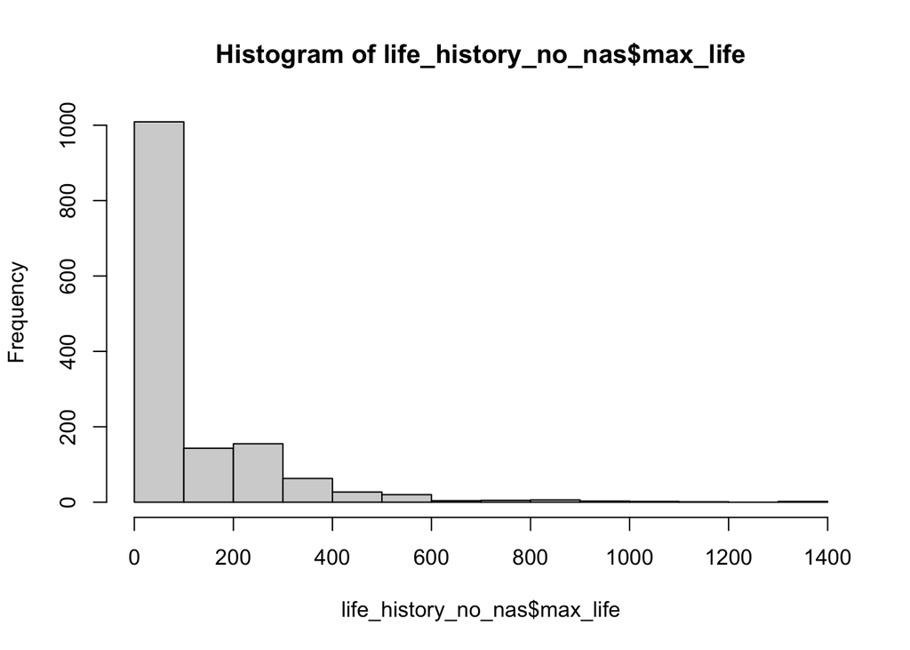

```r
hist(life_history_no_nas$max_life) # we found another way NA's are represented
```

Let’s use `mutate()` and `na_if()` to replace 0’s with NA’s in `max_life`.

```r
life_history_no_nas <-
  life_history_no_nas %>%
  mutate(max_life=na_if(max_life, 0))
```

```r
miss_var_summary(life_history_no_nas)
```

```
## # A tibble: 13 × 3
##    variable     n_miss pct_miss
##    <chr>         <int>    <dbl>
##  1 wean_mass      1039    72.2
##  2 max_life        841    58.4
##  3 litters_year    689    47.8
##  4 weaning         619    43.0
##  5 afr             607    42.2
##  6 gestation       418    29.0
##  7 mass             85     5.90
##  8 litter_size      84     5.83
##  9 order             0     0
## 10 family            0     0
## 11 genus             0     0
## 12 species           0     0
## 13 newborn           0     0
```

We can also use `miss_var_summary` with `group_by()`. This helps us better evaluate where NA’s are in the data.

```r
life_history_no_nas %>%
  group_by(order) %>%
  select(order) %>%
  miss_var_summary(order=T)
```

```
## # A tibble: 0 × 3
## # Groups:   order [0]
## # ℹ 3 variables: order <chr>, n_miss <int>, pct_miss <dbl>
```

`naniar` also has a nice replace function which will allow you to precisely control which values you want replaced with NA’s in each variable.

```r
life_history %>% # going back to original data
  replace_with_na(replace = list(newborn = "not measured",
                                 weaning= -999,
                                 wean_mass= -999,
                                 afr= -999,
                                 max_life= 0,
                                 litter_size= -999,
                                 gestation= -999,
                                 mass= -999)) %>%
miss_var_summary()
```

```
## # A tibble: 13 × 3
##    variable     n_miss pct_miss
##    <chr>         <int>    <dbl>
##  1 wean_mass      1039    72.2
##  2 max_life        841    58.4
##  3 litters_year    689    47.8
##  4 weaning         619    43.0
##  5 afr             607    42.2
##  6 newborn         595    41.3
##  7 gestation       418    29.0
##  8 mass             85     5.90
##  9 litter_size      84     5.83
## 10 order             0     0
## 11 family            0     0
## 12 genus             0     0
## 13 species           0     0
```

```r
# Makes replacement of NA's very specific
```

You can also use naniar to replace a specific value (like -999) with NA across the entire data set.

```r
life_history %>% #going back to the original data
  replace_with_na_all(condition = ~.x == -999)%>%
miss_var_summary()
```

```
## # A tibble: 13 × 3
##    variable     n_miss pct_miss
##    <chr>         <int>    <dbl>
##  1 wean_mass      1039    72.2
##  2 litters_year    689    47.8
##  3 weaning         619    43.0
##  4 afr             607    42.2
##  5 gestation       418    29.0
##  6 mass             85     5.90
##  7 litter_size      84     5.83
##  8 order             0     0
##  9 family            0     0
## 10 genus             0     0
## 11 species           0     0
## 12 newborn           0     0
## 13 max_life          0     0
```

Finally, naniar has some built-in examples of common values or character strings used to represent NA’s. The chunk below will use these built-in parameters to replace NA’s across the entire data set.

```r
common_na_strings
```

```
##  [1] "missing" "NA"      "N A"     "N/A"     "#N/A"    "NA "     " NA"
##  [8] "N /A"    "N / A"   " N / A"  "N / A "  "na"      "n a"     "n/a"
## [15] "na "     " na"     "n /a"    "n / a"   " a / a"  "n / a "  "NULL"
## [22] "null"    ""        "\\?"     "\\*"     "\\."
```

```r
common_na_numbers
```

```
## [1]    -9   -99  -999 -9999  9999    66    77    88
```

```r
life_history %>% #going back to the original data
  replace_with_na_all(condition = ~.x %in% c(common_na_strings, common_na_numbers)) %>%
  mutate(newborn=na_if(newborn, "not measured"))
```

```
## # A tibble: 1,440 × 13
##    order   family genus species   mass gestation newborn weaning wean_mass   afr
##    <chr>   <chr>  <chr> <chr>    <dbl>     <dbl> <chr>     <dbl>     <dbl> <dbl>
##  1 Artiod… Antil… Anti… americ… 4.54e4      8.13 3246.36    3         8900  13.5
##  2 Artiod… Bovid… Addax nasoma… 1.82e5      9.39 5480       6.5         NA  27.3
##  3 Artiod… Bovid… Aepy… melamp… 4.15e4      6.35 5093       5.63     15900  16.7
##  4 Artiod… Bovid… Alce… busela… 1.5 e5      7.9  10166.…    6.5         NA  23.0
##  5 Artiod… Bovid… Ammo… clarkei 2.85e4      6.8  <NA>      NA           NA  NA
##  6 Artiod… Bovid… Ammo… lervia  5.55e4      5.08 3810       4           NA  14.9
##  7 Artiod… Bovid… Anti… marsup… 3   e4      5.72 3910       4.04        NA  10.2
##  8 Artiod… Bovid… Anti… cervic… 3.75e4      5.5  3846       2.13        NA  20.1
##  9 Artiod… Bovid… Bison bison   4.98e5      8.93 20000     10.7     157500  29.4
## 10 Artiod… Bovid… Bison bonasus 5   e5      9.14 23000.…    6.6         NA  30.0
## # ℹ 1,430 more rows
## # ℹ 3 more variables: max_life <dbl>, litter_size <dbl>, litters_year <dbl>
```

## Visualizing NAs

There is another package `visdat` that can be used to visualize the proportion of different classes of data, including missing data. But, it is limited by size.

```r
library(visdat)
```

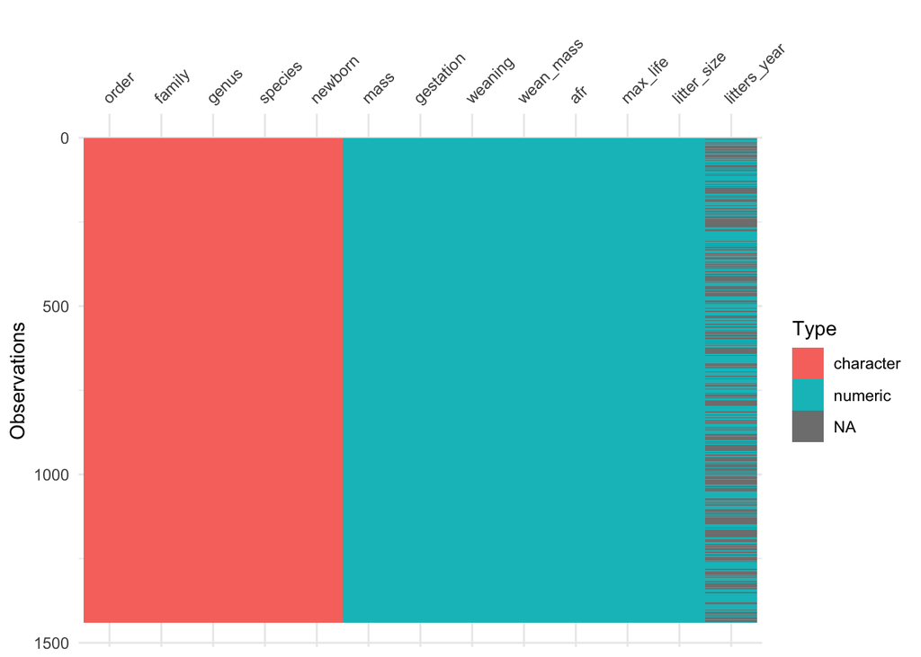

```r
vis_dat(life_history) #classes of data
```

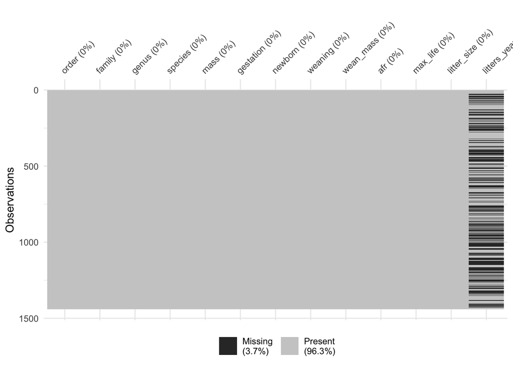

```r
vis_miss(life_history)
```

## Dealing with NA’s in advance

If you are sure that you know how NA’s are treated in the data, then you can deal with them in advance using `na()` as part of the `readr` package.

```r
life_history_advance <-
  readr::read_csv(file = "data_midterm2/mammal_lifehistories_v3.csv",
                  na = c("NA", " ", ".", "-999")) #all NA, blank spaces, .,and -999 are treated as NA
miss_var_summary(life_history_advance)
```

```
## # A tibble: 13 × 3
##    variable     n_miss pct_miss
##    <chr>         <int>    <dbl>
##  1 wean mass      1039    72.2
##  2 litters/year    689    47.8
##  3 weaning         619    43.0
##  4 AFR             607    42.2
##  5 gestation       418    29.0
##  6 mass             85     5.90
##  7 litter size      84     5.83
##  8 order             0     0
##  9 family            0     0
## 10 Genus             0     0
## 11 species           0     0
## 12 newborn           0     0
## 13 max. life         0     0
```